# **Regularization & Generalized Linear Models**

### Part b (5 points)

Using that model, interpret the slope of “service” and the slope of “construction1970-74” in original (not log) units.

```r
coef(poisson_model)
```

```
        (Intercept)               typeB               typeC               typeD
       2.657083e-01        7.030242e-01       -1.196274e+00       -8.319594e-01
              typeE construction1965-69 construction1970-74 construction1975-79
      -2.492144e-01        1.048405e+00        1.446238e+00        6.788384e-01
   operation1975-79             service
       7.030689e-01        6.421118e-05
```

```r
exp(coef(poisson_model)["service"])
```

```
 service
1.000064
```

```r
exp(coef(poisson_model)["construction1970-74"])
```

```
construction1970-74
           4.247106
```

```r
# Each additional unit of service increases the expected number of incidents by 0.0064%.
# Ships constructed in 1970-74 have an expected number of incidents that is 4.24 times that of ships in the reference construction category when all other variables are constant.
```

### Part c (6 points)

Make a residual plot of the Pearson residuals vs the linear predictors and make a QQ plot of the Pearson residuals. Comment on what these imply about the fit.

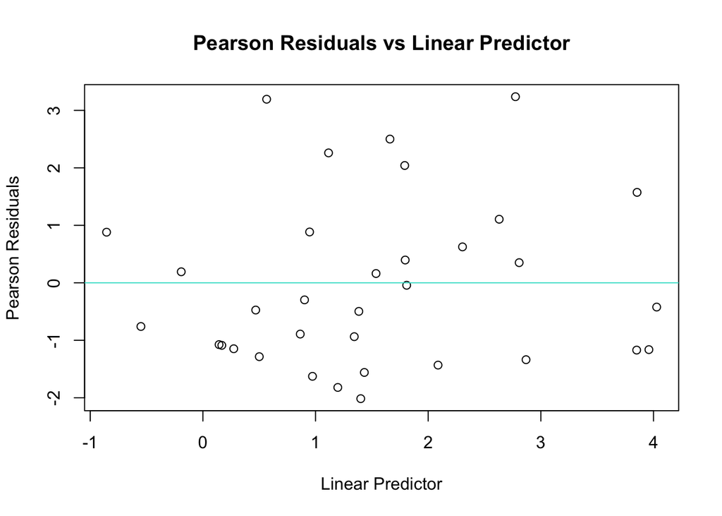

```r
pearson_res = residuals(poisson_model, type = "pearson")
lin_pred = predict(poisson_model, type = "link")
plot(lin_pred, pearson_res,
     xlab = "Linear Predictor",
     ylab = "Pearson Residuals",
     main = "Pearson Residuals vs Linear Predictor")

abline(h = 0, col = "turquoise")
```

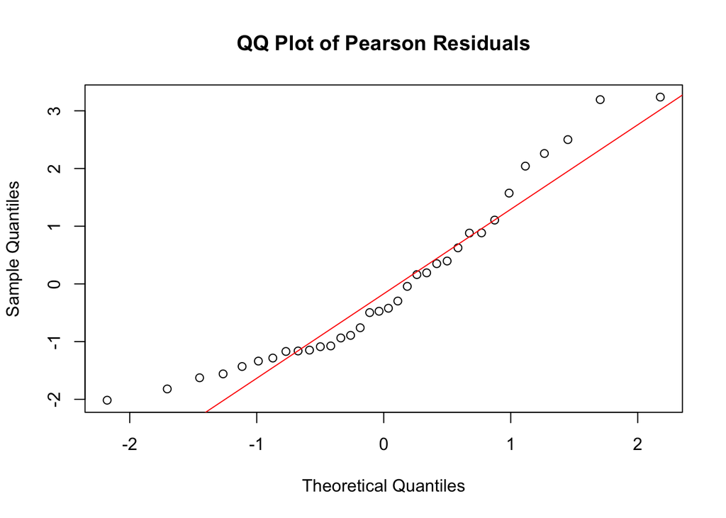

```r
qqnorm(pearson_res, main = "QQ Plot of Pearson Residuals")
qqline(pearson_res, col = "red")
```

```r
# The QQ plot seems to have heavy tails, making the data skewed right. It implies that the distribution is not a good fit.
```

### Part d (5 points)

Conduct a deviance goodness-of-fit (GOF) test for a lack of fit here. Type out the null and alternative hypotheses, report the test statistic, give the p-value, and provide an interpretation.

```r
summary(poisson_model)
```

```
Call:
glm(formula = incidents ~ ., family = "poisson", data = ship_data)

Coefficients:
                      Estimate Std. Error z value Pr(>|z|)
(Intercept)          2.657e-01  2.776e-01   0.957 0.338454
typeB                7.030e-01  2.187e-01   3.214 0.001308 **
typeC               -1.196e+00  3.275e-01  -3.653 0.000259 ***
typeD               -8.320e-01  2.877e-01  -2.892 0.003831 **
typeE               -2.492e-01  2.360e-01  -1.056 0.291027
construction1965-69  1.048e+00  1.798e-01   5.832 5.47e-09 ***
construction1970-74  1.446e+00  2.264e-01   6.387 1.70e-10 ***
construction1975-79  6.788e-01  2.774e-01   2.447 0.014399 *
operation1975-79     7.031e-01  1.358e-01   5.178 2.24e-07 ***
service              6.421e-05  8.593e-06   7.473 7.86e-14 ***
---
Signif. codes:  0 '***' 0.001 '**' 0.01 '*' 0.05 '.' 0.1 ' ' 1

(Dispersion parameter for poisson family taken to be 1)

    Null deviance: 614.54  on 33  degrees of freedom
Residual deviance:  77.45  on 24  degrees of freedom
AIC: 195.32

Number of Fisher Scoring iterations: 5
```

```r
p_value = 1 - pchisq(poisson_model$deviance, poisson_model$df.residual)
p_value
```

```
[1] 1.542447e-07
```

```r
# H0: The Poisson regression model fits the data well
# H1: The Poisson regression model does not fit the data well
# Test stat: D = 77.45 w/ 24 degrees of freedom

# p-value = 1.542447e-07
# Since the p-value is very small, we reject the null hypothesis. Thus, there is evidence that the model does not fit the data well.
```

### Part e (4 points)

Is there evidence that this model has overdispersion? Explain.

```r
dispersion = sum(residuals(poisson_model, type = "pearson")^2) / poisson_model$df.residual
dispersion
```

```
[1] 2.896271
```

```r
# returns 2.896271, which is much greater than 1, so there is evidence of overdispersion. This means it is likely the variance is greater than the mean, which works against the assumptions we made in the using a Poisson distribution.
```

### Part f (6 points)

Fit a “quasipoisson” model to these data. Using this model, obtain an approximate 95% confidence interval for the mean response for a ship of type “B” with construction between 1965 and 1969, with operation between 1960 and 1974, and with 2000 aggregate months of service. You can construct this interval using a t critical value with 24 degrees of freedom since the quasipoisson family more closely follows a t distribution than a normal one. Interpret the interval.

```r
quasi_model = glm(incidents ~ .,
                  data = ship_data,
                  family = "quasipoisson")
new_ship = data.frame(
  type = factor("B", levels = levels(ship_data$type)),
  construction = factor("1965-69", levels = levels(ship_data$construction)),
  operation = factor("1960-74", levels = levels(ship_data$operation)),
  service = 2000
)

pred = predict(quasi_model, newdata = new_ship, se.fit = TRUE, type = "link")

t_crit = qt(0.975, df = 24)

lower_log = pred$fit - t_crit * pred$se.fit
upper_log = pred$fit + t_crit * pred$se.fit

lower = exp(lower_log)
upper = exp(upper_log)

c(lower, upper)
```

```
        1         1
 3.662335 19.945793
```

```r
# lower: 3.66
# upper: 19.95
# We can be 95% confident that the mean number of incidents of ships of type B constructed between 1965-69 that operated between 1960-74 with 2000 months of serves is between 3.66 and 19.95.
```

### Part g (5 points)

Now construct an approximate 95% prediction interval for the number of incidents for the ship described in part f using the `qpois()` function. Interpret the interval.

```r
pred = predict(quasi_model, newdata = new_ship, type = "response")
lambda_hat = pred
lower_pred = qpois(0.025, lambda = lambda_hat)
upper_pred = qpois(0.975, lambda = lambda_hat)

c(lower_pred, upper_pred)
```

```
[1]  3 15
```

```r
# lower: 3
# upper: 15
# We can be 95% confident that the mean number of incidents of ships of type B constructed between 1965-69 that operated between 1960-74 with 2000 months of serves is between 3 and 15.
```

### Part h (6 points)

Suppose we did not catch the fact that this model is overdispersed. Repeat parts f and g using the model fit with the “poisson” family, not “quasipoisson” and using a z interval for the mean response rather than a t interval. Compare your results to parts f and g and comment on what is different.

```r
pred_pois = predict(poisson_model, newdata = new_ship,
                    se.fit = TRUE, type = "link")
z_crit = 1.96

lower_log = pred_pois$fit - z_crit * pred_pois$se.fit
upper_log = pred_pois$fit + z_crit * pred_pois$se.fit

lower_pois = exp(lower_log)
upper_pois = exp(upper_log)

c(lower_pois, upper_pois)
```

```
        1         1
 5.326349 13.714494
```

```r
lambda_hat_pois = predict(poisson_model, newdata = new_ship, type = "response")

lower_pred_pois = qpois(0.025, lambda = lambda_hat_pois)
upper_pred_pois = qpois(0.975, lambda = lambda_hat_pois)

c(lower_pred_pois, upper_pred_pois)
```

```
[1]  3 15
```

```r
# Conf. Int: 5.33 - 13.71
# Prediction Int: 3 - 15
# The Poisson Confidence Interval has a much narrower range than the quasipoisson interval. However, the prediction interval is the same as the one we predicted.
```